# AI CA4 (Machine Learning) - Majid Faridfar

```python
import pandas as pd
import math

DATASET_PATH = "house_data.csv"
```

### Exploratory Data Analysis

At first, we read the dataset and store it in `df` using `pandas` library.

```python
df = pd.read_csv(DATASET_PATH)
```

Now we can observe the overall structure of the dataset using the methods `info()` and `describe()`.

```python
df.info()
```

```
<class 'pandas.core.frame.DataFrame'>
RangeIndex: 21613 entries, 0 to 21612
Data columns (total 27 columns):
 #   Column         Non-Null Count  Dtype
---  ------         --------------  -----
 0   Unnamed: 0.2   21613 non-null  int64
 1   Unnamed: 0.1   21613 non-null  int64
 2   Unnamed: 0     21613 non-null  int64
 3   id             21613 non-null  int64
 4   date           21613 non-null  object
 5   price          21613 non-null  float64
 6   bedrooms       21613 non-null  int64
 7   bathrooms      21613 non-null  float64
 8   sqft_living    18528 non-null  float64
 9   sqft_lot       21613 non-null  int64
```

[output cut: 19 more lines]

As you can see, this `info` method shows us the general information of different data columns (which are our features here), including:

- number of valid data
- data type of the values

Also, at the end, we see the memory usage of dataset and all the data types we have.

```python
df.describe()
```

|  | Unnamed: 0.2 | Unnamed: 0.1 | Unnamed: 0 | id | price | bedrooms | bathrooms | sqft_living | sqft_lot | floors | ... | sqft_above | sqft_basement | yr_built | yr_renovated | zipcode | lat | long | sqft_living15 | sqft_lot15 | house_age |
| --- | --- | --- | --- | --- | --- | --- | --- | --- | --- | --- | --- | --- | --- | --- | --- | --- | --- | --- | --- | --- | --- |
| count | 21613.00000 | 21613.00000 | 21613.00000 | 2.161300e+04 | 2.161300e+04 | 21613.000000 | 21613.000000 | 18528.000000 | 2.161300e+04 | 18530.000000 | ... | 21613.000000 | 21184.000000 | 18531.000000 | 21613.000000 | 21613.000000 | 21613.000000 | 21613.000000 | 21613.000000 | 21613.000000 | 21613.000000 |
| mean | 10806.00000 | 10806.00000 | 10806.00000 | 4.580302e+09 | 5.401822e+05 | 3.367464 | 2.111900 | 2077.569031 | 1.510697e+04 | 1.492903 | ... | 1788.390691 | 292.121082 | 1970.896714 | 84.402258 | 98077.939805 | 47.560053 | -122.213896 | 1986.552492 | 12768.455652 | 50.994864 |
| std | 6239.28002 | 6239.28002 | 6239.28002 | 2.876566e+09 | 3.673622e+05 | 0.943028 | 0.780697 | 953.971679 | 4.142051e+04 | 0.538562 | ... | 828.090978 | 442.637777 | 29.406420 | 401.679240 | 53.505026 | 0.138564 | 0.140828 | 685.391304 | 27304.179631 | 29.373411 |
| min | 0.00000 | 0.00000 | 0.00000 | 1.000102e+06 | 7.500000e+04 | -5.000000 | -5.000000 | -33323.000000 | 5.200000e+02 | 1.000000 | ... | 290.000000 | 0.000000 | 1900.000000 | 0.000000 | 98001.000000 | 47.155900 | -122.519000 | 399.000000 | 651.000000 | 7.000000 |
| 25% | 5403.00000 | 5403.00000 | 5403.00000 | 2.123049e+09 | 3.219500e+05 | 3.000000 | 1.750000 | 1430.000000 | 5.040000e+03 | 1.000000 | ... | 1190.000000 | 0.000000 | 1951.000000 | 0.000000 | 98033.000000 | 47.471000 | -122.328000 | 1490.000000 | 5100.000000 | 25.000000 |
| 50% | 10806.00000 | 10806.00000 | 10806.00000 | 3.904930e+09 | 4.500000e+05 | 3.000000 | 2.250000 | 1920.000000 | 7.618000e+03 | 1.500000 | ... | 1560.000000 | 0.000000 | 1975.000000 | 0.000000 | 98065.000000 | 47.571800 | -122.230000 | 1840.000000 | 7620.000000 | 47.000000 |
| 75% | 16209.00000 | 16209.00000 | 16209.00000 | 7.308900e+09 | 6.450000e+05 | 4.000000 | 2.500000 | 2550.000000 | 1.068800e+04 | 2.000000 | ... | 2210.000000 | 560.000000 | 1996.000000 | 0.000000 | 98118.000000 | 47.678000 | -122.125000 | 2360.000000 | 10083.000000 | 71.000000 |
| max | 21612.00000 | 21612.00000 | 21612.00000 | 9.900000e+09 | 7.700000e+06 | 33.000000 | 8.000000 | 13540.000000 | 1.651359e+06 | 3.500000 | ... | 9410.000000 | 4820.000000 | 2015.000000 | 2015.000000 | 98199.000000 | 47.777600 | -121.315000 | 6210.000000 | 871200.000000 | 122.000000 |

8 rows × 24 columns

The `describe` method gives us more information for the numerical columns of the data set:

In this way, we can get a more comprehensive view of the data set.

Now, we get the number of missing data for each column (feature) using the `isna()` method

```python
df.isna().sum()
```

```
Unnamed: 0.2        0
Unnamed: 0.1        0
Unnamed: 0          0
id                  0
date                0
price               0
bedrooms            0
bathrooms           0
sqft_living      3085
sqft_lot            0
floors           3083
waterfront          0
view                0
condition           0
grade               0
sqft_above          0
sqft_basement     429
yr_built         3082
yr_renovated        0
zipcode             0
lat                 0
long                0
sqft_living15       0
sqft_lot15          0
location            0
style               0
house_age           0
dtype: int64
```

Also, by dividing this number by the total number of data, we can also get the percentage of these missing data.

```python
percent_missing = df.isna().sum()*100/df.shape[0]
display(percent_missing)
```

```
Unnamed: 0.2      0.000000
Unnamed: 0.1      0.000000
Unnamed: 0        0.000000
id                0.000000
date              0.000000
price             0.000000
bedrooms          0.000000
bathrooms         0.000000
sqft_living      14.273817
sqft_lot          0.000000
floors           14.264563
waterfront        0.000000
view              0.000000
condition         0.000000
grade             0.000000
sqft_above        0.000000
sqft_basement     1.984916
yr_built         14.259936
yr_renovated      0.000000
zipcode           0.000000
lat               0.000000
long              0.000000
sqft_living15     0.000000
sqft_lot15        0.000000
location          0.000000
style             0.000000
house_age         0.000000
dtype: float64
```

Now we want to see the correlation graph of the features. For this we use the `sns` library.

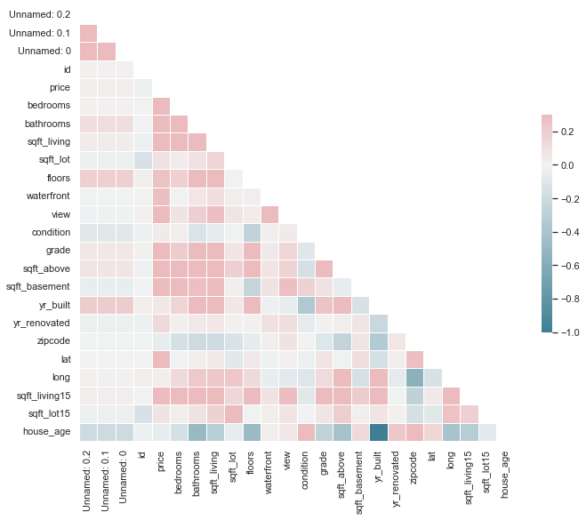

```python
import seaborn as sns
import matplotlib.pyplot as plt
import numpy as np

corr_matrix = df.corr(numeric_only=True) #.style.background_gradient(cmap='coolwarm')

# plt.figure(figsize=(15, 15))
# sns.heatmap(corr_matrix, annot=True, fmt='.0%')

sns.set(style="white")

mask = np.zeros_like(corr_matrix, dtype=bool)
mask[np.triu_indices_from(mask)] = True

f, ax = plt.subplots(figsize=(11, 9))

cmap = sns.diverging_palette(220, 10, as_cmap=True)

sns.heatmap(corr_matrix, mask=mask, cmap=cmap, vmax=.3, center=0,
            square=True, linewidths=.5, cbar_kws={"shrink": .5})
```

Based on the obtained graph, we can identify the features that are more dependent on the target column (house prices). In the following, you can see these values sorted.

```python
corr_bests = df.corr(numeric_only=True)["price"].sort_values(ascending=False)
display(corr_bests)
```

```
price            1.000000
sqft_living      0.676542
sqft_above       0.605566
sqft_living15    0.585374
bathrooms        0.517952
view             0.397346
grade            0.389227
sqft_basement    0.321825
lat              0.306919
bedrooms         0.304521
waterfront       0.266331
floors           0.258603
yr_renovated     0.126442
sqft_lot         0.089655
sqft_lot15       0.082456
yr_built         0.054118
condition        0.036392
Unnamed: 0.2     0.027344
Unnamed: 0.1     0.027344
Unnamed: 0       0.027344
long             0.021571
id              -0.016797
zipcode         -0.053168
house_age       -0.053982
Name: price, dtype: float64
```

So, features **sqft_living**, **sqft_above**, **sqft_living15** and **bathrooms** are the most dependent on the price of the house, respectively, with more than 50% crrelation.

Now, for the mentioned features, we draw the observation graph of each unique value.

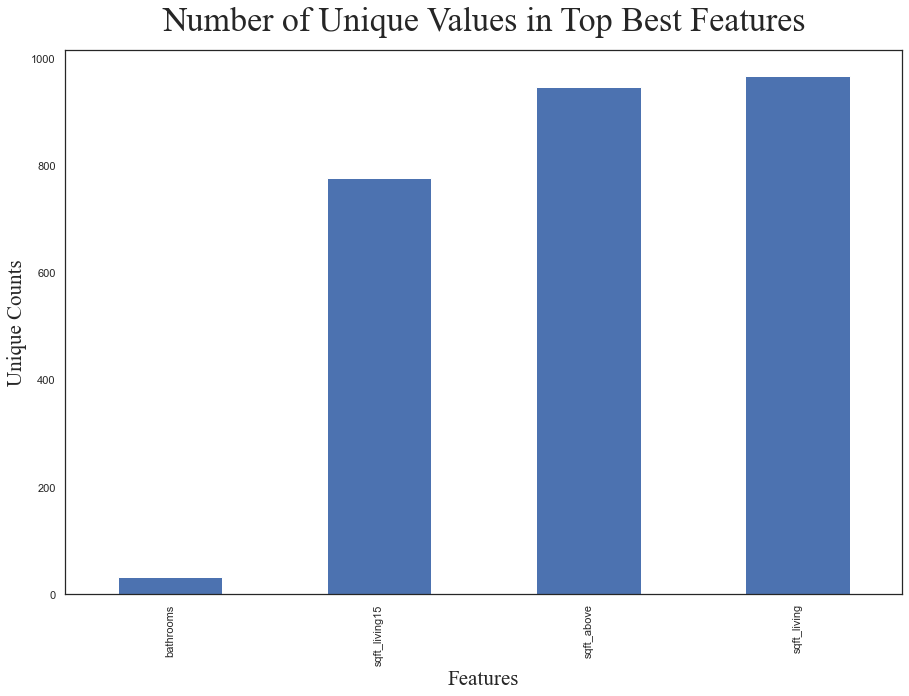

```python
unique_values = df[corr_bests[1:5].index].apply(pd.Series.nunique)
unique_values = unique_values.sort_values()

unique_values.plot(kind='bar', figsize=(15, 10))
plt.xlabel('Features', fontdict={'fontsize': 21, 'fontfamily': 'Times New Roman'})
plt.ylabel('Unique Counts', fontdict={'fontsize': 21, 'fontfamily': 'Times New Roman'})
plt.title('Number of Unique Values in Top Best Features', fontdict={'fontsize': 34, 'fontfamily': 'Times New Roman'}, pad=20)
plt.show()
```

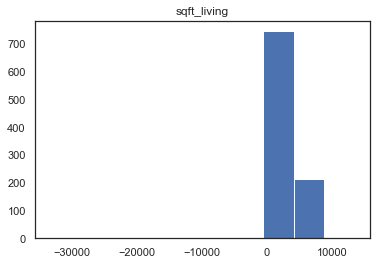

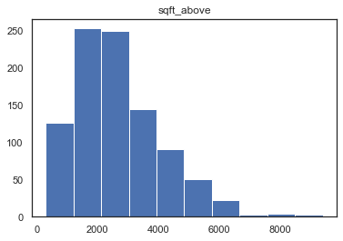

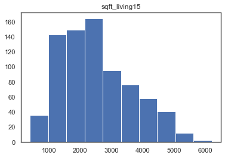

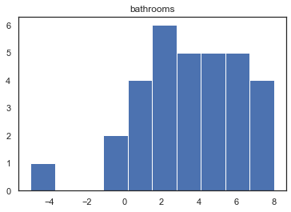

```python
for feature in list(corr_bests.index)[1:5]:
    plt.figure()
    unique_values = np.unique(df[feature])
    plt.hist(unique_values)
#     plt.hist(df[feature])
    plt.title(feature)
    plt.show()
```

Also, by using `scatter` and `hexbin` diagrams, we can check the correlation of features in a more detailed way.

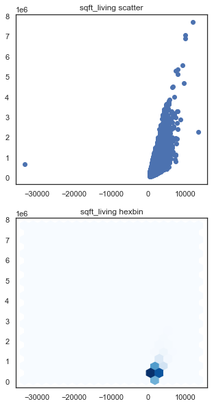

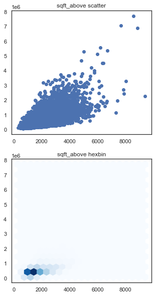

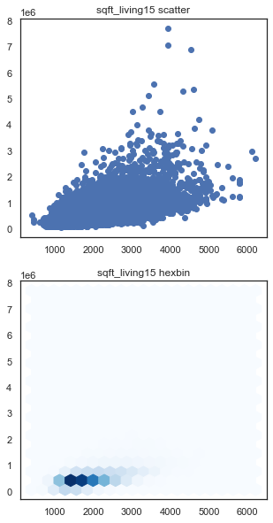

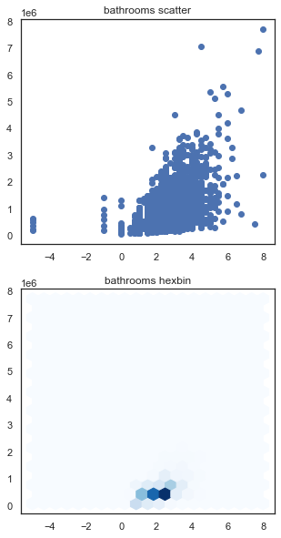

```python
for feature in list(corr_bests.index)[1:5]:
    fig, axes = plt.subplots(nrows=2, figsize=(5, 10))
    axes[0].scatter(df[feature], df["price"])
    axes[0].set_title(feature + " scatter")

    axes[1].hexbin(df[feature], df["price"], gridsize=20, cmap='Blues')
    axes[1].set_title(feature + " hexbin")
```

- **scatter plot** displays the relationship between two variables as a set of points on a two-dimensional coordinate system. Each point represents an observation in the dataset, where the x-axis corresponds to one variable and the y-axis corresponds to the other variable. The position of each point on the plot represents the values of the two variables for that observation. Scatter plots are commonly used to identify patterns and trends in the data, as well as to detect outliers and anomalies.
- **hexbin plot**, on the other hand, is similar to a scatter plot but uses hexagons instead of points to represent the data. The hexagons are colored according to the number of observations that fall within each hexagon, with darker colors indicating higher densities of points. Hexbin plots are useful when dealing with large datasets, as they can help to visualize the overall distribution of the data more clearly than scatter plots.

### Preprocessing the dataset

**Solving the problem of missing values**

> 1. **Drop columns that have missing values**: In this case, we lose one of the features that may contain useful values if this problem is solved. So, if the number of these lost data is not very high, it does not seem to be a suitable method.
> 2. **Fill in the blanks with stats (like mode)**: By doing this, the variance of the data will be disturbed and also, the general distribution of the data may be disturbed, which is not desirable.
> 3. **Drop rows that contain missing values**: By deleting the data, the distribution of other features may be disturbed. So, like the first case, it is not a good thing.
> 4. **Filling blank values with average data in the column (for numeric columns)**: It has the same problem as the second method.
> 5. **Filling the blank values with the most repeated data in the column**: It has the same problem as the second method.
> 6. **Using predictive algorithm to predict missing values**: It means creating a predictive model to estimate values that will substitute the missing data. In this case, we divide our data set into two sets: One set with no missing values for the variable and another one with missing values. We then use the set with no missing values to create a model that will predict the missing values in the other set. There are several techniques for imputation using predictive algorithms such as:
>    - K-nearest neighbor (KNN) algorithm
>    - Random Forest
>    - Neural Networks
>    - Decision Trees

At first, it is necessary to replace the values that are wrong with the `NaN`. For this purpose, according to my research, I will describe each of the features in the dataset.

1. `Unnamed: 0.2`, `Unnamed: 0.1`, `Unnamed: 0`: It seems they don't contain any useful information.
2. `id`: A unique identifier for each house in the dataset.
3. `date`: The date that the house was sold.
4. `price`: The sale price of the house.
5. `bedrooms`: The number of bedrooms in the house.
6. `bathrooms`: The number of bathrooms in the house.
7. `sqft_living`: The total living area of the house in square feet.
8. `sqft_lot`: The total lot area of the house in square feet.
9. `floors`: The number of floors in the house.
10. `waterfront`: A binary variable indicating whether the house has a waterfront view (1) or not (0).
11. `view`: A rating of the house's view, on a scale of 0-4.
12. `condition`: A rating of the house's overall condition, on a scale of 1-5.
13. `grade`: A rating of the house's overall construction quality, on a scale of 1-13.
14. `sqft_above`: The living area of the house above ground level, in square feet.
15. `sqft_basement`: The living area of the house below ground level, in square feet.
16. `yr_built`: The year that the house was built.
17. `yr_renovated`: The year that the house was last renovated.
18. `zipcode`: The zipcode of the area where the house is located.
19. `lat`: The latitude of the house's location.
20. `long`: The longitude of the house's location.
21. `sqft_living15`: The average living area of the 15 nearest houses in the dataset, in square feet.
22. `sqft_lot15`: The average lot area of the 15 nearest houses in the dataset, in square feet.
23. `location`: The location of the house, possibly as a text string.
24. `style`: The architectural style of the house, possibly as a text string.
25. `house_age`: The age of the house in years.

In this way, for numeric columns, we can replace data that does not conform to the specified format.

```python
df.isna().sum()

df.loc[df['price'] <= 0, 'price'] = np.nan
df.loc[df['bedrooms'] < 0, 'bedrooms'] = np.nan

df['bathrooms'] = df['bathrooms'].round()
df.loc[df['bathrooms'] < 0, 'bathrooms'] = np.nan

df.loc[df['sqft_living'] <= 0, 'sqft_living'] = np.nan
df.loc[df['sqft_lot'] <= 0, 'sqft_lot'] = np.nan
# df.loc[(df['floors'] <= 0) | (~df['floors'].astype(int).eq(df['floors'])), 'floors'] = np.nan
df.loc[df['floors'] <= 0, 'floors'] = np.nan
df.loc[~df['waterfront'].between(0, 1), 'waterfront'] = np.nan
df.loc[~df['view'].between(0, 4), 'view'] = np.nan
df.loc[~df['condition'].between(1, 5), 'condition'] = np.nan
df.loc[~df['grade'].between(1, 13), 'grade'] = np.nan
df.loc[df['sqft_above'] <= 0, 'sqft_above'] = np.nan
df.loc[df['sqft_basement'] < 0, 'sqft_basement'] = np.nan
df.loc[df['yr_built'] < 0, 'yr_built'] = np.nan
df.loc[df['yr_renovated'] < 0, 'yr_renovated'] = np.nan
df.loc[df['sqft_living15'] <= 0, 'sqft_living15'] = np.nan
df.loc[df['sqft_lot15'] <= 0, 'sqft_lot15'] = np.nan
df.loc[df['house_age'] < 0, 'house_age'] = np.nan

df.isna().sum()
```

```
Unnamed: 0.2        0
Unnamed: 0.1        0
Unnamed: 0          0
id                  0
date                0
price               0
bedrooms           12
bathrooms          12
sqft_living      3086
sqft_lot            0
floors           3083
waterfront          0
view                0
condition           0
grade               1
sqft_above          0
sqft_basement     429
yr_built         3082
yr_renovated        0
zipcode             0
lat                 0
long                0
sqft_living15       0
sqft_lot15          0
location            0
style               0
house_age           0
dtype: int64
```

```python
rows_max = df.isnull().sum(axis=1).max()
missing_price = df[df['price'].isnull()]

print("Maximum number of missing values in rows of the dataset:", rows_max)
print("Maximum ratio of missing values in columns of the dataset:", str(percent_missing.max()) + "%")
print("Number of rows, which their 'price' is null:", len(missing_price))

df.describe()
```

```
Maximum number of missing values in rows of the dataset: 3
Maximum ratio of missing values in columns of the dataset: 14.273816684402906%
Number of rows, which their 'price' is null: 0
```

|  | Unnamed: 0.2 | Unnamed: 0.1 | Unnamed: 0 | id | price | bedrooms | bathrooms | sqft_living | sqft_lot | floors | ... | sqft_above | sqft_basement | yr_built | yr_renovated | zipcode | lat | long | sqft_living15 | sqft_lot15 | house_age |
| --- | --- | --- | --- | --- | --- | --- | --- | --- | --- | --- | --- | --- | --- | --- | --- | --- | --- | --- | --- | --- | --- |
| count | 21613.00000 | 21613.00000 | 21613.00000 | 2.161300e+04 | 2.161300e+04 | 21601.000000 | 21601.000000 | 18527.000000 | 2.161300e+04 | 18530.000000 | ... | 21613.000000 | 21184.000000 | 18531.000000 | 21613.000000 | 21613.000000 | 21613.000000 | 21613.000000 | 21613.000000 | 21613.000000 | 21613.000000 |
| mean | 10806.00000 | 10806.00000 | 10806.00000 | 4.580302e+09 | 5.401822e+05 | 3.371001 | 2.058655 | 2079.479786 | 1.510697e+04 | 1.492903 | ... | 1788.390691 | 292.121082 | 1970.896714 | 84.402258 | 98077.939805 | 47.560053 | -122.213896 | 1986.552492 | 12768.455652 | 50.994864 |
| std | 6239.28002 | 6239.28002 | 6239.28002 | 2.876566e+09 | 3.673622e+05 | 0.930074 | 0.755372 | 917.857260 | 4.142051e+04 | 0.538562 | ... | 828.090978 | 442.637777 | 29.406420 | 401.679240 | 53.505026 | 0.138564 | 0.140828 | 685.391304 | 27304.179631 | 29.373411 |
| min | 0.00000 | 0.00000 | 0.00000 | 1.000102e+06 | 7.500000e+04 | 0.000000 | 0.000000 | 290.000000 | 5.200000e+02 | 1.000000 | ... | 290.000000 | 0.000000 | 1900.000000 | 0.000000 | 98001.000000 | 47.155900 | -122.519000 | 399.000000 | 651.000000 | 7.000000 |
| 25% | 5403.00000 | 5403.00000 | 5403.00000 | 2.123049e+09 | 3.219500e+05 | 3.000000 | 2.000000 | 1430.000000 | 5.040000e+03 | 1.000000 | ... | 1190.000000 | 0.000000 | 1951.000000 | 0.000000 | 98033.000000 | 47.471000 | -122.328000 | 1490.000000 | 5100.000000 | 25.000000 |
| 50% | 10806.00000 | 10806.00000 | 10806.00000 | 3.904930e+09 | 4.500000e+05 | 3.000000 | 2.000000 | 1920.000000 | 7.618000e+03 | 1.500000 | ... | 1560.000000 | 0.000000 | 1975.000000 | 0.000000 | 98065.000000 | 47.571800 | -122.230000 | 1840.000000 | 7620.000000 | 47.000000 |
| 75% | 16209.00000 | 16209.00000 | 16209.00000 | 7.308900e+09 | 6.450000e+05 | 4.000000 | 2.000000 | 2550.000000 | 1.068800e+04 | 2.000000 | ... | 2210.000000 | 560.000000 | 1996.000000 | 0.000000 | 98118.000000 | 47.678000 | -122.125000 | 2360.000000 | 10083.000000 | 71.000000 |
| max | 21612.00000 | 21612.00000 | 21612.00000 | 9.900000e+09 | 7.700000e+06 | 33.000000 | 8.000000 | 13540.000000 | 1.651359e+06 | 3.500000 | ... | 9410.000000 | 4820.000000 | 2015.000000 | 2015.000000 | 98199.000000 | 47.777600 | -121.315000 | 6210.000000 | 871200.000000 | 122.000000 |

8 rows × 24 columns

Because the number of missing data in each row is at most 3 and the percentage of missing data in dataset columns is at most 14.27%, also we don't have any rows where the price field is missing, so we don't drop any rows or columns. Also, since both of these values are small, we can fill them with median.

```python
df.fillna(df.median(numeric_only=True), inplace=True)
display(df.isna().sum())
df.describe()
```

```
Unnamed: 0.2     0
Unnamed: 0.1     0
Unnamed: 0       0
id               0
date             0
price            0
bedrooms         0
bathrooms        0
sqft_living      0
sqft_lot         0
floors           0
waterfront       0
view             0
condition        0
grade            0
sqft_above       0
sqft_basement    0
yr_built         0
yr_renovated     0
zipcode          0
lat              0
long             0
sqft_living15    0
sqft_lot15       0
location         0
style            0
house_age        0
dtype: int64
```

|  | Unnamed: 0.2 | Unnamed: 0.1 | Unnamed: 0 | id | price | bedrooms | bathrooms | sqft_living | sqft_lot | floors | ... | sqft_above | sqft_basement | yr_built | yr_renovated | zipcode | lat | long | sqft_living15 | sqft_lot15 | house_age |
| --- | --- | --- | --- | --- | --- | --- | --- | --- | --- | --- | --- | --- | --- | --- | --- | --- | --- | --- | --- | --- | --- |
| count | 21613.00000 | 21613.00000 | 21613.00000 | 2.161300e+04 | 2.161300e+04 | 21613.000000 | 21613.000000 | 21613.000000 | 2.161300e+04 | 21613.000000 | ... | 21613.000000 | 21613.000000 | 21613.00000 | 21613.000000 | 21613.000000 | 21613.000000 | 21613.000000 | 21613.000000 | 21613.000000 | 21613.000000 |
| mean | 10806.00000 | 10806.00000 | 10806.00000 | 4.580302e+09 | 5.401822e+05 | 3.370795 | 2.058622 | 2056.708555 | 1.510697e+04 | 1.493916 | ... | 1788.390691 | 286.322722 | 1971.48184 | 84.402258 | 98077.939805 | 47.560053 | -122.213896 | 1986.552492 | 12768.455652 | 50.994864 |
| std | 6239.28002 | 6239.28002 | 6239.28002 | 2.876566e+09 | 3.673622e+05 | 0.929856 | 0.755164 | 851.633193 | 4.142051e+04 | 0.498677 | ... | 828.090978 | 440.112814 | 27.26682 | 401.679240 | 53.505026 | 0.138564 | 0.140828 | 685.391304 | 27304.179631 | 29.373411 |
| min | 0.00000 | 0.00000 | 0.00000 | 1.000102e+06 | 7.500000e+04 | 0.000000 | 0.000000 | 290.000000 | 5.200000e+02 | 1.000000 | ... | 290.000000 | 0.000000 | 1900.00000 | 0.000000 | 98001.000000 | 47.155900 | -122.519000 | 399.000000 | 651.000000 | 7.000000 |
| 25% | 5403.00000 | 5403.00000 | 5403.00000 | 2.123049e+09 | 3.219500e+05 | 3.000000 | 2.000000 | 1502.000000 | 5.040000e+03 | 1.000000 | ... | 1190.000000 | 0.000000 | 1955.00000 | 0.000000 | 98033.000000 | 47.471000 | -122.328000 | 1490.000000 | 5100.000000 | 25.000000 |
| 50% | 10806.00000 | 10806.00000 | 10806.00000 | 3.904930e+09 | 4.500000e+05 | 3.000000 | 2.000000 | 1920.000000 | 7.618000e+03 | 1.500000 | ... | 1560.000000 | 0.000000 | 1975.00000 | 0.000000 | 98065.000000 | 47.571800 | -122.230000 | 1840.000000 | 7620.000000 | 47.000000 |
| 75% | 16209.00000 | 16209.00000 | 16209.00000 | 7.308900e+09 | 6.450000e+05 | 4.000000 | 2.000000 | 2420.000000 | 1.068800e+04 | 2.000000 | ... | 2210.000000 | 550.000000 | 1992.00000 | 0.000000 | 98118.000000 | 47.678000 | -122.125000 | 2360.000000 | 10083.000000 | 71.000000 |
| max | 21612.00000 | 21612.00000 | 21612.00000 | 9.900000e+09 | 7.700000e+06 | 33.000000 | 8.000000 | 13540.000000 | 1.651359e+06 | 3.500000 | ... | 9410.000000 | 4820.000000 | 2015.00000 | 2015.000000 | 98199.000000 | 47.777600 | -121.315000 | 6210.000000 | 871200.000000 | 122.000000 |

8 rows × 24 columns

We can also drop the first four columns (`Unnamed: 0.2`, `Unnamed: 0.1`, `Unnamed: 0`, `id`) that do not give us useful information.

```python
df = df.drop('Unnamed: 0.2', axis=1).drop('Unnamed: 0.1', axis=1).drop('Unnamed: 0', axis=1).drop('id', axis=1)
df.describe()
```

|  | price | bedrooms | bathrooms | sqft_living | sqft_lot | floors | waterfront | view | condition | grade | sqft_above | sqft_basement | yr_built | yr_renovated | zipcode | lat | long | sqft_living15 | sqft_lot15 | house_age |
| --- | --- | --- | --- | --- | --- | --- | --- | --- | --- | --- | --- | --- | --- | --- | --- | --- | --- | --- | --- | --- |
| count | 2.161300e+04 | 21613.000000 | 21613.000000 | 21613.000000 | 2.161300e+04 | 21613.000000 | 21613.000000 | 21613.000000 | 21613.000000 | 21613.000000 | 21613.000000 | 21613.000000 | 21613.00000 | 21613.000000 | 21613.000000 | 21613.000000 | 21613.000000 | 21613.000000 | 21613.000000 | 21613.000000 |
| mean | 5.401822e+05 | 3.370795 | 2.058622 | 2056.708555 | 1.510697e+04 | 1.493916 | 0.007542 | 0.234303 | 3.409430 | 7.656873 | 1788.390691 | 286.322722 | 1971.48184 | 84.402258 | 98077.939805 | 47.560053 | -122.213896 | 1986.552492 | 12768.455652 | 50.994864 |
| std | 3.673622e+05 | 0.929856 | 0.755164 | 851.633193 | 4.142051e+04 | 0.498677 | 0.086517 | 0.766318 | 0.650743 | 1.175459 | 828.090978 | 440.112814 | 27.26682 | 401.679240 | 53.505026 | 0.138564 | 0.140828 | 685.391304 | 27304.179631 | 29.373411 |
| min | 7.500000e+04 | 0.000000 | 0.000000 | 290.000000 | 5.200000e+02 | 1.000000 | 0.000000 | 0.000000 | 1.000000 | 1.000000 | 290.000000 | 0.000000 | 1900.00000 | 0.000000 | 98001.000000 | 47.155900 | -122.519000 | 399.000000 | 651.000000 | 7.000000 |
| 25% | 3.219500e+05 | 3.000000 | 2.000000 | 1502.000000 | 5.040000e+03 | 1.000000 | 0.000000 | 0.000000 | 3.000000 | 7.000000 | 1190.000000 | 0.000000 | 1955.00000 | 0.000000 | 98033.000000 | 47.471000 | -122.328000 | 1490.000000 | 5100.000000 | 25.000000 |
| 50% | 4.500000e+05 | 3.000000 | 2.000000 | 1920.000000 | 7.618000e+03 | 1.500000 | 0.000000 | 0.000000 | 3.000000 | 7.000000 | 1560.000000 | 0.000000 | 1975.00000 | 0.000000 | 98065.000000 | 47.571800 | -122.230000 | 1840.000000 | 7620.000000 | 47.000000 |
| 75% | 6.450000e+05 | 4.000000 | 2.000000 | 2420.000000 | 1.068800e+04 | 2.000000 | 0.000000 | 0.000000 | 4.000000 | 8.000000 | 2210.000000 | 550.000000 | 1992.00000 | 0.000000 | 98118.000000 | 47.678000 | -122.125000 | 2360.000000 | 10083.000000 | 71.000000 |
| max | 7.700000e+06 | 33.000000 | 8.000000 | 13540.000000 | 1.651359e+06 | 3.500000 | 1.000000 | 4.000000 | 5.000000 | 13.000000 | 9410.000000 | 4820.000000 | 2015.00000 | 2015.000000 | 98199.000000 | 47.777600 | -121.315000 | 6210.000000 | 871200.000000 | 122.000000 |

**For categorical features, which are usually stored as string or object in data frame, what preprocessings are useful? Are these methods necessary for all of these columns?**

> For categorical features stored as strings or objects in a data frame, there are several preprocessing methods that can be useful, including:
> 1. **Label Encoding**: This method assigns a unique numerical label to each category in the column, thereby converting the categorical data into numerical data that can be used by machine learning algorithms. However, it is important to note that label encoding does not create any ranking or order of the categories, and therefore may not be appropriate for all categorical features.
> 2. **One-Hot Encoding**: This method creates a new binary column for each category in the original column. Each row in the new columns is assigned a value of 1 if the corresponding category is present in the original column, and 0 otherwise. One-hot encoding is useful when there are multiple categories in a column and there is no natural ordering or ranking among them.
> 3. **Binary Encoding**: This method is similar to one-hot encoding, but instead of creating a new column for each category, it creates a binary representation of the category using the existing columns. This can help reduce the dimensionality of the dataset and improve the efficiency of the machine learning algorithms.
> 4. **Frequency Encoding**: This method replaces each category with its frequency or count in the dataset. This can be useful when there are a large number of categories in a column and one-hot encoding would result in a high-dimensional feature space.

> The choice of preprocessing method for categorical features depends on the specific characteristics of the data and the problem at hand. Not all preprocessing methods are necessary for all categorical columns, and it is important to carefully consider the impact of each method on the analysis and prediction. For example, label encoding may be appropriate for categorical features that have a natural ordering or ranking, while one-hot encoding may be more appropriate for features with multiple categories and no natural ordering. Similarly, binary encoding may be useful for high-dimensional data, while frequency encoding may be appropriate for features with a large number of categories.

First, we identify the non-numeric columns.

```python
cat_cols = df.select_dtypes(include=['object']).columns.tolist()
print(cat_cols)
```

```
['date', 'location', 'style']
```

To encode the `date` column, we use the `to_datetime` function. In this way, more detailed information is obtained from this column.

```python
df['year'] = df['date'].str[:4].astype(int)
df['month'] = df['date'].str[4:6].astype(int)
df['day'] = df['date'].str[6:8].astype(int)

df['date_num'] = pd.to_datetime(df[['year', 'month', 'day']]).astype('int64')
df = df.drop(['date', 'year', 'month', 'day'], axis=1)

df.describe()
```

|  | price | bedrooms | bathrooms | sqft_living | sqft_lot | floors | waterfront | view | condition | grade | ... | sqft_basement | yr_built | yr_renovated | zipcode | lat | long | sqft_living15 | sqft_lot15 | house_age | date_num |
| --- | --- | --- | --- | --- | --- | --- | --- | --- | --- | --- | --- | --- | --- | --- | --- | --- | --- | --- | --- | --- | --- |
| count | 2.161300e+04 | 21613.000000 | 21613.000000 | 21613.000000 | 2.161300e+04 | 21613.000000 | 21613.000000 | 21613.000000 | 21613.000000 | 21613.000000 | ... | 21613.000000 | 21613.00000 | 21613.000000 | 21613.000000 | 21613.000000 | 21613.000000 | 21613.000000 | 21613.000000 | 21613.000000 | 2.161300e+04 |
| mean | 5.401822e+05 | 3.370795 | 2.058622 | 2056.708555 | 1.510697e+04 | 1.493916 | 0.007542 | 0.234303 | 3.409430 | 7.656873 | ... | 286.322722 | 1971.48184 | 84.402258 | 98077.939805 | 47.560053 | -122.213896 | 1986.552492 | 12768.455652 | 50.994864 | 1.414557e+18 |
| std | 3.673622e+05 | 0.929856 | 0.755164 | 851.633193 | 4.142051e+04 | 0.498677 | 0.086517 | 0.766318 | 0.650743 | 1.175459 | ... | 440.112814 | 27.26682 | 401.679240 | 53.505026 | 0.138564 | 0.140828 | 685.391304 | 27304.179631 | 29.373411 | 9.767348e+15 |
| min | 7.500000e+04 | 0.000000 | 0.000000 | 290.000000 | 5.200000e+02 | 1.000000 | 0.000000 | 0.000000 | 1.000000 | 1.000000 | ... | 0.000000 | 1900.00000 | 0.000000 | 98001.000000 | 47.155900 | -122.519000 | 399.000000 | 651.000000 | 7.000000 | 1.398989e+18 |
| 25% | 3.219500e+05 | 3.000000 | 2.000000 | 1502.000000 | 5.040000e+03 | 1.000000 | 0.000000 | 0.000000 | 3.000000 | 7.000000 | ... | 0.000000 | 1955.00000 | 0.000000 | 98033.000000 | 47.471000 | -122.328000 | 1490.000000 | 5100.000000 | 25.000000 | 1.405987e+18 |
| 50% | 4.500000e+05 | 3.000000 | 2.000000 | 1920.000000 | 7.618000e+03 | 1.500000 | 0.000000 | 0.000000 | 3.000000 | 7.000000 | ... | 0.000000 | 1975.00000 | 0.000000 | 98065.000000 | 47.571800 | -122.230000 | 1840.000000 | 7620.000000 | 47.000000 | 1.413418e+18 |
| 75% | 6.450000e+05 | 4.000000 | 2.000000 | 2420.000000 | 1.068800e+04 | 2.000000 | 0.000000 | 0.000000 | 4.000000 | 8.000000 | ... | 550.000000 | 1992.00000 | 0.000000 | 98118.000000 | 47.678000 | -122.125000 | 2360.000000 | 10083.000000 | 71.000000 | 1.424131e+18 |
| max | 7.700000e+06 | 33.000000 | 8.000000 | 13540.000000 | 1.651359e+06 | 3.500000 | 1.000000 | 4.000000 | 5.000000 | 13.000000 | ... | 4820.000000 | 2015.00000 | 2015.000000 | 98199.000000 | 47.777600 | -121.315000 | 6210.000000 | 871200.000000 | 122.000000 | 1.432685e+18 |

8 rows × 21 columns

We also use the `label coding` method to encode the `location` and `style` columns.

```python
from sklearn.preprocessing import LabelEncoder

location_le = LabelEncoder()
style_le = LabelEncoder()

df['location'] = location_le.fit_transform(df['location'])
df['style'] = style_le.fit_transform(df['style'])

df.info()
```

```
<class 'pandas.core.frame.DataFrame'>
RangeIndex: 21613 entries, 0 to 21612
Data columns (total 23 columns):
 #   Column         Non-Null Count  Dtype
---  ------         --------------  -----
 0   price          21613 non-null  float64
 1   bedrooms       21613 non-null  float64
 2   bathrooms      21613 non-null  float64
 3   sqft_living    21613 non-null  float64
 4   sqft_lot       21613 non-null  float64
 5   floors         21613 non-null  float64
 6   waterfront     21613 non-null  float64
 7   view           21613 non-null  float64
 8   condition      21613 non-null  float64
 9   grade          21613 non-null  float64
 10  sqft_above     21613 non-null  float64
 11  sqft_basement  21613 non-null  float64
 12  yr_built       21613 non-null  float64
 13  yr_renovated   21613 non-null  float64
 14  zipcode        21613 non-null  int64
 15  lat            21613 non-null  float64
 16  long           21613 non-null  float64
 17  sqft_living15  21613 non-null  float64
 18  sqft_lot15     21613 non-null  float64
 19  location       21613 non-null  int32
 20  style          21613 non-null  int32
 21  house_age      21613 non-null  float64
 22  date_num       21613 non-null  int64
dtypes: float64(19), int32(2), int64(2)
memory usage: 3.6 MB
```

**Is it possible to drop some columns? Why?**

> Yes, it is possible to drop some columns from a dataset. There are several reasons why we might want to drop columns:
> 1. **Reducing Dimensionality**: Removing columns can help simplify the dataset and reduce its dimensionality. This can be particularly useful when dealing with large datasets or when the model is computationally expensive.
> 2. **Irrelevant or Redundant Information**: Some columns may contain irrelevant or redundant information that does not contribute to the analysis or prediction. Dropping these columns can help improve the accuracy of the model by reducing noise and focusing on relevant information.
> 3. **Missing or Incomplete Data**: Some columns may have a large number of missing or incomplete data points. In such cases, dropping these columns can help avoid bias and ensure that the model is trained on complete data.

> However, it is important to be cautious when dropping columns and to carefully consider the impact on the model and the analysis. Dropping important columns can lead to loss of valuable information and potentially impact the accuracy of the model. Therefore, it is important to carefully analyze the dataset and determine which columns can be safely dropped without affecting the quality of the analysis or prediction.

**What is the purpose of normalizing and standardizing in numerical features? Is there a need to do this in this project?**

> The purpose of normalizing and standardizing numerical features in a dataset is to ensure that each feature is on a similar scale and has a similar range of values. This can be important for machine learning algorithms that use distance-based calculations, such as k-nearest neighbors (k-NN) and support vector machines (SVM).Normalization and standardization are both methods of scaling the data, but they differ in the way they adjust the values of the features:
> - **Normalization**: This method scales the data so that it ranges from 0 to 1. It is calculated by subtracting the minimum value of the feature and dividing by the range (i.e., the difference between the maximum and minimum values).
> - **Standardization**: This method scales the data so that it has a mean of 0 and a standard deviation of 1. It is calculated by subtracting the mean of the feature and dividing by the standard deviation.

> Normalization and standardization can improve the performance of machine learning algorithms by Reducing the impact of outliers, Improving convergence, and Improving the accuracy of models.

> Improving the accuracy of models: Scaling the data can help machine learning algorithms better distinguish between features that are important and those that are less important.

> The choice of normalization or standardization method depends on the specific characteristics of the data and the machine learning algorithm being used. In general, normalization is useful when the feature values have a clear minimum and maximum range, while standardization is useful when the feature values are not bounded and have a Gaussian-like distribution.

> Since the range of different features is different, we standardize the data.

```python
from sklearn.preprocessing import StandardScaler

cols = df.columns
cols = cols.delete(cols.get_loc('price'))
scaler = StandardScaler()

df_standardized = pd.DataFrame(scaler.fit_transform(df[cols]), columns=cols, index=df.index)
df_standardized = pd.concat([df['price'], df_standardized], axis=1)

df_standardized.describe()
```

|  | price | bedrooms | bathrooms | sqft_living | sqft_lot | floors | waterfront | view | condition | grade | ... | yr_renovated | zipcode | lat | long | sqft_living15 | sqft_lot15 | location | style | house_age | date_num |
| --- | --- | --- | --- | --- | --- | --- | --- | --- | --- | --- | --- | --- | --- | --- | --- | --- | --- | --- | --- | --- | --- |
| count | 2.161300e+04 | 2.161300e+04 | 21613.000000 | 2.161300e+04 | 2.161300e+04 | 2.161300e+04 | 2.161300e+04 | 2.161300e+04 | 2.161300e+04 | 2.161300e+04 | ... | 2.161300e+04 | 2.161300e+04 | 2.161300e+04 | 2.161300e+04 | 2.161300e+04 | 2.161300e+04 | 2.161300e+04 | 2.161300e+04 | 21613.000000 | 2.161300e+04 |
| mean | 5.401822e+05 | 1.341329e-16 | 0.000000 | -1.157225e-16 | 1.052023e-17 | -2.419652e-16 | -5.260114e-18 | -1.052023e-17 | -2.577456e-16 | 2.524855e-16 | ... | 1.315028e-18 | -8.962149e-14 | -3.432290e-14 | -3.667614e-14 | 8.153176e-17 | -2.893063e-17 | 1.052023e-17 | -7.101154e-17 | 0.000000 | -1.283205e-14 |
| std | 3.673622e+05 | 1.000023e+00 | 1.000023 | 1.000023e+00 | 1.000023e+00 | 1.000023e+00 | 1.000023e+00 | 1.000023e+00 | 1.000023e+00 | 1.000023e+00 | ... | 1.000023e+00 | 1.000023e+00 | 1.000023e+00 | 1.000023e+00 | 1.000023e+00 | 1.000023e+00 | 1.000023e+00 | 1.000023e+00 | 1.000023 | 1.000023e+00 |
| min | 7.500000e+04 | -3.625155e+00 | -2.726124 | -2.074543e+00 | -3.521759e-01 | -9.904746e-01 | -8.717263e-02 | -3.057595e-01 | -3.702668e+00 | -5.663344e+00 | ... | -2.101284e-01 | -1.438025e+00 | -2.916795e+00 | -2.166543e+00 | -2.316325e+00 | -4.438052e-01 | -1.599980e+00 | -1.454404e+00 | -1.497813 | -1.593989e+00 |
| 25% | 3.219500e+05 | -3.987755e-01 | -0.077630 | -6.513619e-01 | -2.430487e-01 | -9.904746e-01 | -8.717263e-02 | -3.057595e-01 | -6.291869e-01 | -5.588357e-01 | ... | -2.101284e-01 | -8.399369e-01 | -6.426977e-01 | -8.102505e-01 | -7.244971e-01 | -2.808593e-01 | -2.633340e-01 | -6.860335e-01 | -0.885000 | -8.774623e-01 |
| 50% | 4.500000e+05 | -3.987755e-01 | -0.077630 | -1.605289e-01 | -1.808075e-01 | 1.220116e-02 | -8.717263e-02 | -3.057595e-01 | -6.291869e-01 | -5.588357e-01 | ... | -2.101284e-01 | -2.418484e-01 | 8.478232e-02 | -1.143518e-01 | -2.138280e-01 | -1.885636e-01 | -2.633340e-01 | 8.233682e-02 | -0.136006 | -1.167060e-01 |
| 75% | 6.450000e+05 | 6.766843e-01 | -0.077630 | 4.265919e-01 | -1.066880e-01 | 1.014877e+00 | -8.717263e-02 | -3.057595e-01 | 9.075535e-01 | 2.919156e-01 | ... | -2.101284e-01 | 7.487357e-01 | 8.512345e-01 | 6.312541e-01 | 5.448802e-01 | -9.835556e-02 | 1.073312e+00 | 8.507071e-01 | 0.681079 | 9.801984e-01 |
| max | 7.700000e+06 | 3.186502e+01 | 7.867850 | 1.348416e+01 | 3.950434e+01 | 4.022904e+00 | 1.147149e+01 | 4.914129e+00 | 2.444294e+00 | 4.545672e+00 | ... | 4.806428e+00 | 2.262647e+00 | 1.570054e+00 | 6.383070e+00 | 6.162239e+00 | 3.144029e+01 | 1.073312e+00 | 1.619077e+00 | 2.417383 | 1.855953e+00 |

8 rows × 23 columns

**To train and finally evaluate the machine learning model, it is necessary to divide the data into two groups, training and testing. What is the ratio of this division? What are the ways to divide and build these two categories?**

> The ratio of dividing data into training and testing sets can vary depending on the size of the dataset and the complexity of the model. However, a commonly used ratio is 70:30 or 80:20, where 70% or 80% of the data is used for training the model and the remaining 30% or 20% is used for testing the model.

> There are several ways to divide the data into training and testing sets:
> 1. **Simple Hold-Out Method**: In this method, the dataset is randomly split into two sets, one for training the model and the other for testing the model. This method is simple but may result in biased estimates if the dataset is not representative of the population.
> 2. **K-Fold Cross-Validation**: In this method, the dataset is divided into K equal-sized subsets, with K-1 subsets used for training the model and the remaining subset used for testing the model. This process is repeated K times, with each subset serving as the testing set once. This method is more robust than the simple hold-out method and can provide a more accurate estimate of model performance.
> 3. **Stratified Sampling**: In some cases, the dataset may not be evenly distributed across all classes or categories. In such cases, stratified sampling can be used to ensure that the training and testing datasets are representative of the population. In this method, the dataset is divided into strata or subgroups based on a specific attribute, and the training and testing sets are created by sampling from each stratum.
> 4. **Time-Based Splitting**: In some cases, the data may have a temporal or time-based component. In such cases, it is important to split the data into training and testing sets based on time. The training set should contain data from earlier time periods, while the testing set should contain data from later time periods. This method ensures that the model is evaluated on data that it has not seen before.

> Overall, the choice of splitting method depends on the specific characteristics of the dataset and the problem at hand. A well-designed split can help ensure that the model is accurately trained and evaluated, leading to better predictions and insights.

**Sometimes, in addition to the two categories of training and testing, we also have another category. Explain about this category (validation).**

> In addition to the training and testing datasets, it is common to also have a third category known as the validation dataset. The validation dataset is used to evaluate the performance of the model during the training process and to tune the model's hyperparameters.

> During the training process, the model is typically trained on the training dataset and evaluated on the validation dataset after each epoch or iteration. This allows us to monitor the model's performance and adjust the hyperparameters to improve the model's accuracy. The validation dataset is used to prevent overfitting, which occurs when the model becomes too complex and fits too closely to the training data, resulting in poor performance on new or unseen data.

> The validation dataset is different from the testing dataset in that it is not used to evaluate the final performance of the model. Instead, the testing dataset is used to evaluate the performance of the model after it has been fully trained and fine-tuned on the training and validation datasets. The testing dataset provides an unbiased estimate of the model's performance on new or unseen data.

> Overall, the use of a validation dataset is an important step in the machine learning process. It allows us to fine-tune the model's hyperparameters and prevent overfitting, leading to a more accurate and robust model.

```python
from sklearn.model_selection import train_test_split

x_train, x_test, y_train, y_test = train_test_split(df_standardized.drop('price', axis=1), df_standardized['price'], test_size=0.2, random_state=39)
```

### Training, evaluation and regulation

#### 1. Linear Regression

Main form of simple linear regression function: $$f(x) = \alpha x + \beta$$

- step 1: Compute RSS of the training data

$$ RSS = \Sigma (y_i - (\hat{\beta} + \hat{\alpha} * x_i) )^2 $$

- step 2: Compute the derivatives of the RSS function in term of $\underline{\alpha}$ and $\underline{\beta}$, and set them equal to 0 to find the desired parameters

$$ \frac{\partial RSS}{\partial \beta} = \Sigma (-f(x_i) + \hat{\beta} + \hat{\alpha} * x_i) = 0$$$$ \to \hat{\beta} = \hat{y} - \hat{\alpha} \hat{x} \to (1)$$$$ \frac{\partial RSS}{\partial \alpha} = \Sigma (-2 x_i y_i + 2 \hat{\beta} x_i + 2\hat{\alpha} x_i ^ 2) = 0 \to (2)$$$$ (1) , (2) \to \hat{\alpha} = \frac{\Sigma{(x_i - \hat{x})(y_i - \hat{y})}}{\Sigma{(x_i - \hat{x})^2}} $$

$$ \hat{\beta} = \hat{y} - \hat{\alpha} \hat{x}$$

Based on the formula above, we write this function to compute the parameters of a simple linear regression.

```python
def simple_linear_regression(input_feature, output):
    n = len(input_feature)

    # compute the sum of input_feature and output, and the averages
    sum_xi = sum(input_feature)
    sum_yi = sum(output)

    avg_x = sum_xi/n
    avg_y = sum_yi/n

    # compute the product of difference between the output and average of
    # it and differnce between input_feature and the average, and its sum
    x_y = sum((input_feature - avg_x)*(output - avg_y))

    # compute the squared value of the input_feature and its sum
    x_2 = sum((input_feature - avg_x)**2)

    # use the formula for the slope
    intercept = x_y/x_2

    # use the formula for the intercept
    slope = avg_y - (intercept*avg_x)

    return (intercept, slope)
```

And this function, which predicts the value of given data based on the calculated intercept and slope.

```python
def get_regression_predictions(input_feature, intercept, slope):
    # calculate the predicted values
    predicted_values = (intercept*input_feature + slope)

    return (predicted_values)
```

Now that we have a model and can make predictions let's evaluate our model using Root Mean Square Error (RSME). RMSE is the square root of the mean of the squared differences between the residuals and the residuals is just a fancy word for the difference between the predicted output and the true output.

The following function computes the RSME of a simple linear regression model given the input_feature, output, intercept and slope.

```python
import math

def get_root_mean_square_error(predicted_values , output):
    n = len(predicted_values)

    # Compute the residuals (since we are squaring it doesn't matter which order you subtract)
    residuals = predicted_values - output

    # square the residuals and add them up
    sum_residuals2 = sum(residuals**2)

    # find the mean of the above phrase
    mean_residuals2 = sum_residuals2/n

    # calculate the root
    RMSE = math.sqrt(mean_residuals2)

    return(RMSE)
```

The RMSE has no bound and it is not easy to find out the percentage of fitting the model into data with it. instead, we use R2 score. The R2 score is calculated by comparing the sum of the squared differences between the actual and predicted values of the dependent variable to the total sum of squared differences between the actual and mean values of the dependent variable. Matematically, the R2 score formula is shown as follows:

$$R^2 = 1 - \frac{SSres}{SStot} = 1 - \frac{\sum_{i=1}^{n} (y_{i,true} - y_{i,pred})^2}{\sum_{i=1}^{n} (y_{i,true} - \bar{y}_{true})^2} $$

The following function calculates the R2 score of a given input_feature, output, intercept, and slope:

```python
def get_r2_score(predicted_values, output):
    n = len(predicted_values)

    # then compute the residuals (since we are squaring it doesn't matter which order you subtract)
    residuals = output - predicted_values

    # square the residuals and add them up -> SSres
    SSres = sum(residuals**2)

    # compute the SStot
    avg_output = sum(output)/n
    SStot = sum((output - avg_output)**2)

    # compute the R2 score value
    R2_score = 1 - (SSres/SStot)

    return(R2_score)
```

In regression analysis, several performance metrics are used to evaluate the accuracy of the prediction model. Four commonly used metrics are:

**Residual Sum of Squares (RSS)**: The RSS is a measure of the difference between the predicted and actual values of the dependent variable. It is used to assess how well a regression model fits the data. A lower RSS indicates a better fit of the model to the data. However, RSS alone does not provide a sense of the scale of the error, since it depends on the number of observations in the dataset. Therefore, it is often normalized by dividing it by the number of degrees of freedom in the model to obtain the mean square error (MSE). Mathematically, RSS is defined as:

$$RSS = Σ(y - ŷ)^2$$

where $y$ is the actual value of the dependent variable, $ŷ$ is the predicted value of the dependent variable, and Σ is the sum over all the observations in the dataset.

**Mean Squared Error (MSE)**: The MSE is the average of the squared differences between the predicted and actual values of the dependent variable. It provides a measure of the magnitude of the error, and is useful for comparing the performance of different models. A smaller MSE indicates a better fit of the model to the data. Mathematically, MSE is defined as:

$$MSE = \frac{RSS}{n}$$

where $n$ is the number of observations in the dataset.

**Root Mean Squared Error (RMSE)**: The RMSE is the square root of the MSE. It provides a measure of the average magnitude of the error in the same units as the dependent variable. The RMSE is often used in practice because it is easier to interpret than the MSE. Mathematically, RMSE is defined as:

$$RMSE = \sqrt{MSE}$$

**R-squared (R2) Score**: The R2 score is a measure of how well a regression model fits the data. It is the proportion of the variance in the dependent variable that is explained by the independent variable. A higher R2 score indicates a better fit of the model to the data. The R2 score can be interpreted as the percentage of the total variation in the dependent variable that is explained by the independent variable. However, the R2 score has some limitations. For example, it can be biased towards models with more independent variables, and it does not provide information about the precision of the estimates. Mathematically, R2 score is defined as:

$$R2 = 1 - \frac{RSS}{TSS}$$

Now we calculate the fitness of the model.

Since we have obtained a 1-fold regression model, and we can only give it one feature as input, it is better to go for the feature that has a higher correlation with the price column. As we calculated before, features **sqft_living**, **sqft_above**, **sqft_living15** and **bathrooms**, which have more than 50% correlation, will probably give us a more accurate output and are more suitable.

```python
designated_feature_list = ['sqft_living', 'sqft_above', 'sqft_living15', 'grade' , 'bathrooms' , 'yr_built' , 'zipcode']

for feature in designated_feature_list:
    # calculate R2 score and RMSE for each given feature

    intercept, slope = simple_linear_regression(x_train[feature], y_train)
    predicted_values = get_regression_predictions(x_test[feature], intercept, slope)

    print("*** Feature:", feature)
    print("RSME:", get_root_mean_square_error(predicted_values, y_test))
    print("R2 Score:", get_r2_score(predicted_values, y_test))
    print()
```

```
*** Feature: sqft_living
RSME: 278747.4821847116
R2 Score: 0.41606357980179787

*** Feature: sqft_above
RSME: 293375.6832176388
R2 Score: 0.3531674229503371

*** Feature: sqft_living15
RSME: 295770.5047920531
R2 Score: 0.34256415123742334

*** Feature: grade
RSME: 274704.7655592324
R2 Score: 0.43287858913340527

*** Feature: bathrooms
RSME: 311943.22356373817
R2 Score: 0.2687013560764089

*** Feature: yr_built
RSME: 364871.7582847344
R2 Score: -0.0005162705539047963

*** Feature: zipcode
RSME: 364282.1160859277
R2 Score: 0.0027148369014325935
```

According to the explanations that were given for the `R2 score` and `RSME`, we notice that for the data we identified, they have a higher correlation with the price column, in general, better results have been obtained (i.e., a higher R2 score, and a lower RSME).

Similarly, the results of the `zipcode` and `yr_built` cases were weaker because they gave a low `R2 score` and a higher `RSME`. Which of course was expected because logically they don't fit well with the target column. That means, for example, the postal code cannot have a great impact on the price of the house! Or it may be that an old house is much more expensive than a newly built house, so general conclusions cannot be made.

It should also be noted that `grade` and `sqft_living` have achieved the best results. Which of course is logical. Because the size of the house and its points and facilities have a direct effect on the price of the house.

#### 2. Classification

Because we are dealing with a calcification problem, at first we add a new column to the data frame named `price_level`. In this way, if the value of the `price` was higher than the median, the value of this column is `HIGH` and if it was lower, the value of this column is `LOW`. Now we do the classification for this column.

```python
median = df_standardized['price'].median()
# df_standardized['price_level'] = [("HIGH" if df_standardized.loc[i, 'price'] > median else "LOW") for i in range(df_standardized.shape[0])]
df_standardized['price_level'] = [(1 if df_standardized.loc[i, 'price'] > median else 0) for i in range(df_standardized.shape[0])]

display(df_standardized)
```

|  | price | bedrooms | bathrooms | sqft_living | sqft_lot | floors | waterfront | view | condition | grade | ... | zipcode | lat | long | sqft_living15 | sqft_lot15 | location | style | house_age | date_num | price_level |
| --- | --- | --- | --- | --- | --- | --- | --- | --- | --- | --- | --- | --- | --- | --- | --- | --- | --- | --- | --- | --- | --- |
| 0 | 221900.0 | -0.398775 | -1.401877 | -1.029468 | -0.228321 | -0.990475 | -0.087173 | -0.305759 | -0.629187 | -0.558836 | ... | 1.870152 | -0.352572 | -0.306079 | -0.943355 | -0.260715 | -0.263334 | 0.082337 | 0.544898 | -0.143244 | 0 |
| 1 | 538000.0 | -0.398775 | -0.077630 | 0.602728 | -0.189885 | 0.012201 | -0.087173 | -0.305759 | -0.629187 | -0.558836 | ... | 0.879568 | 1.161568 | -0.746341 | -0.432686 | -0.187868 | -0.263334 | 0.850707 | 0.681079 | 0.360978 | 1 |
| 2 | 180000.0 | -1.474235 | -1.401877 | -1.510907 | -0.123298 | -0.990475 | -0.087173 | -0.305759 | -0.629187 | -1.409587 | ... | -0.933388 | 1.283537 | -0.135655 | 1.070140 | -0.172375 | -1.599980 | 1.619077 | 1.293892 | 1.050966 | 0 |
| 3 | 604000.0 | 0.676684 | 1.246617 | -0.113559 | -0.244014 | -0.990475 | -0.087173 | -0.305759 | 2.444294 | -0.558836 | ... | 1.085160 | -0.283288 | -1.271816 | -0.914174 | -0.284522 | 1.073312 | -0.686033 | 0.204446 | 0.360978 | 1 |
| 4 | 510000.0 | -0.398775 | -0.077630 | -0.442347 | -0.169653 | -0.990475 | -0.087173 | -0.305759 | -0.629187 | 0.291916 | ... | -0.073636 | 0.409550 | 1.199335 | -0.272190 | -0.192849 | -0.263334 | -1.454404 | -0.544548 | 0.989044 | 1 |
| ... | ... | ... | ... | ... | ... | ... | ... | ... | ... | ... | ... | ... | ... | ... | ... | ... | ... | ... | ... | ... | ... |
| 21608 | 360000.0 | -0.398775 | -0.077630 | -0.618483 | -0.337424 | 3.020228 | -0.087173 | -0.305759 | -0.629187 | 0.291916 | ... | 0.468382 | 1.004958 | -0.938069 | -0.666135 | -0.412381 | -0.263334 | 1.619077 | -1.293542 | -1.425915 | 0 |
| 21609 | 400000.0 | 0.676684 | -0.077630 | 0.297425 | -0.224386 | 1.014877 | -0.087173 | -0.305759 | -0.629187 | 0.291916 | ... | 1.272063 | -0.356180 | -1.051685 | -0.228419 | -0.203946 | -0.263334 | -1.454404 | -1.463768 | 1.033274 | 0 |
| 21610 | 402101.0 | -1.474235 | -1.401877 | -1.217346 | -0.332137 | 0.012201 | -0.087173 | -0.305759 | -0.629187 | -0.558836 | ... | 1.234683 | 0.247888 | -0.604321 | -1.410253 | -0.394141 | -0.263334 | 0.850707 | -1.293542 | -1.133996 | 0 |
| 21611 | 400000.0 | -0.398775 | -0.077630 | -0.536286 | -0.307076 | 1.014877 | -0.087173 | -0.305759 | -0.629187 | 0.291916 | ... | -0.952078 | -0.184414 | 1.028910 | -0.841221 | -0.420511 | -1.599980 | 0.082337 | -1.123316 | 0.697126 | 0 |
| 21612 | 325000.0 | -1.474235 | -1.401877 | -1.217346 | -0.338752 | 0.012201 | -0.087173 | -0.305759 | -0.629187 | -0.558836 | ... | 1.234683 | 0.245723 | -0.604321 | -1.410253 | -0.417948 | -1.599980 | 0.850707 | -1.259497 | -0.125552 | 0 |

21613 rows × 24 columns

Also, once again, we generate training and test data. (this time according to the `price_level` column)

```python
x = df_standardized.drop('price_level', axis=1).drop('price', axis=1)
y = df_standardized['price_level']

x_train, x_test, y_train, y_test = train_test_split(x, y, test_size=0.2, random_state=42)
```

##### K-Nearest-Neighbors

We use `KNeighborClassifier` function, which is in implemented in `scikit learn` library. At first, we train it with the train data and then make predictions with the generated model on the test data. Finally, we obtain the accuracy value of the model using the `accuracy_score` function.

```python
from sklearn.neighbors import KNeighborsClassifier
from sklearn.metrics import confusion_matrix, accuracy_score

knn = KNeighborsClassifier()
knn.fit(x_train, y_train)

y_pred = knn.predict(x_test)

accuracy = accuracy_score(y_test, y_pred)
print("Accuracy:", accuracy)
```

```
Accuracy: 0.8584316446911867
```

Now, using `confusion_matrix` function, we obtain the confusion matrix and display it.

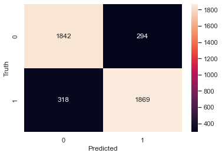

```python
cm = confusion_matrix(y_test, y_pred)

sns.heatmap(cm, annot=True, fmt='d')
plt.xlabel('Predicted')
plt.ylabel('Truth')
```

The four cells of the confusion matrix represent the number of instances that fall into each of the following categories:

- **True positives (TP)**: The number of instances that are correctly predicted as positive (belonging to the positive class).
- **False positives (FP)**: The number of instances that are incorrectly predicted as positive (belonging to the negative class, but predicted as positive).
- **False negatives (FN)**: The number of instances that are incorrectly predicted as negative (belonging to the positive class, but predicted as negative).
- **True negatives (TN)**: The number of instances that are correctly predicted as negative (belonging to the negative class).

The accuracy of a classification model is defined as the proportion of correctly predicted instances (TP and TN) out of the total number of instances (TP, TN, FP, and FN). The formula for accuracy is:

$$Accuracy = \frac{TP + TN}{TP + TN + FP + FN} = \frac{1869 + 1842}{1869 + 318 + 294 + 1842} = 0.8584$$

This formula counts the number of instances that are correctly classified (TP and TN) and divides it by the total number of instances in the dataset. The resulting value is a percentage that represents the overall accuracy of the model in predicting the correct class label.

You can see the calculated accuracy here, is equal to the output of function `accuracy_score`, which I've printed.

```python
from sklearn.model_selection import GridSearchCV

knn_params = {'n_neighbors': [3, 5, 7, 9, 11, 13, 15]}

knn = KNeighborsClassifier()
knn_grid = GridSearchCV(knn, knn_params, cv=5)

knn_grid.fit(x, y)

print("KNN best parameters:", knn_grid.best_params_)
print("KNN best score:", knn_grid.best_score_)
```

```
KNN best parameters: {'n_neighbors': 15}
KNN best score: 0.8605007084669101
```

```
Number of Decision Trees: 1
```

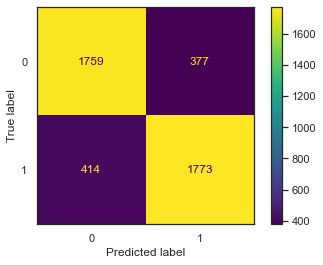

```
Number of Decision Trees: 2
```

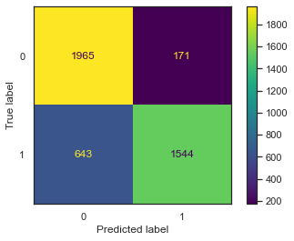

```
Number of Decision Trees: 3
```

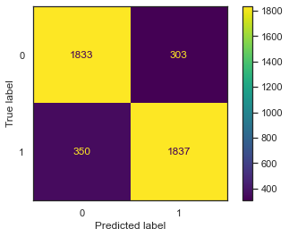

```
Number of Decision Trees: 4
```

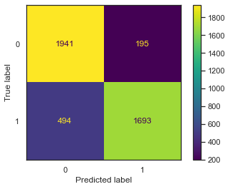

```
Number of Decision Trees: 5
```

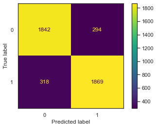

```
Number of Decision Trees: 6
```

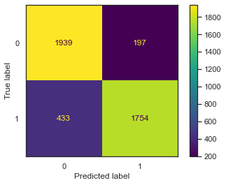

```
Number of Decision Trees: 7
```

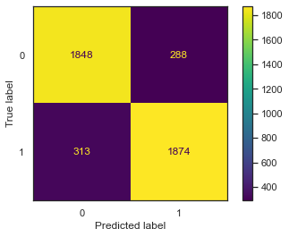

```
Number of Decision Trees: 8
```

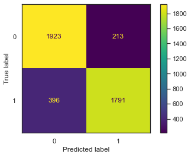

```
Number of Decision Trees: 9
```

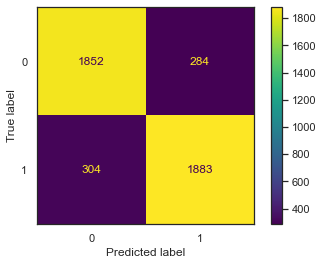

```
Number of Decision Trees: 10
```

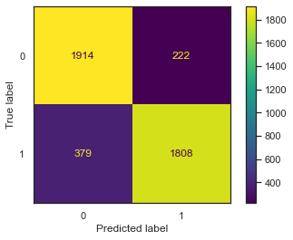

```
Number of Decision Trees: 11
```

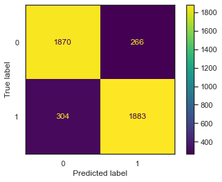

```
Number of Decision Trees: 12
```

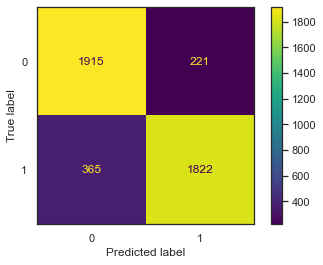

```
Number of Decision Trees: 13
```

[18 more figures not shown]

```python
from sklearn.metrics import ConfusionMatrixDisplay

knn_acc=[]

for i in range(1, 31):
    predicted_tmp=[]
    knn_i = KNeighborsClassifier(n_neighbors=i)
    knn_i.fit(x_train, y_train)
    y_pred_i = knn_i.predict(x_test)

    knn_acc.append(accuracy_score(y_test, y_pred_i))
    cm = confusion_matrix(y_test, y_pred_i)

    cm_display = ConfusionMatrixDisplay(cm, display_labels = [0,1])
    cm_display.plot()
    print("Number of Decision Trees:", i)
    plt.show()
```

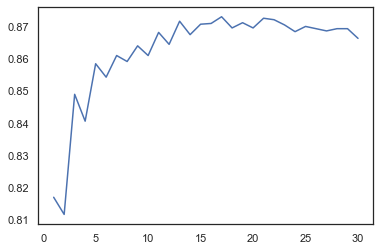

```python
x_arr=[i for i in range(1,31)]
plt.plot(x_arr, knn_acc)
plt.show()
```

It can be seen that the accuracy increases with the increase of the number of neighbors, but it decreases from one place to the next, which indicates overfitting.

##### Decision Tree

We use `DecisionTreeClassifier` function, which is in implemented in `scikit learn` library. At first, we train it with the train data and then make predictions with the generated model on the test data. Finally, we obtain the accuracy value of the model using the `accuracy_score` function.

```python
from sklearn.tree import DecisionTreeClassifier

dtc = DecisionTreeClassifier(max_depth=5)
dtc.fit(x_train, y_train)

y_pred = dtc.predict(x_test)

accuracy = accuracy_score(y_test, y_pred)
print("Accuracy:", accuracy)
```

```
Accuracy: 0.8746241036317373
```

Now, using `confusion_matrix` function, we obtain the confusion matrix and display it.

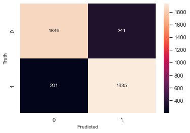

```python
cm = confusion_matrix(y_test, y_pred)

sns.heatmap(cm, annot=True, fmt='d')
plt.xlabel('Predicted')
plt.ylabel('Truth')
```

The accuracy of a classification model is defined as the proportion of correctly predicted instances (TP and TN) out of the total number of instances (TP, TN, FP, and FN):

$$Accuracy = \frac{TP + TN}{TP + TN + FP + FN} = \frac{1846 + 1935}{1846 + 341 + 201 + 1935} = 0.8746$$

By using `GridSearchCV` function, we can get the best possible parameters for the model, which gives us the most accurate results.

Based on the researchs I did, this model has various parameters, which are described here:

- `criterion`: Function to measure the quality of a split (str, 'gini' or 'entropy')
- `splitter`: Strategy used to choose the split at each node (str, 'best' or 'random')
- `max_depth`: Maximum depth of the tree (int)
- `min_samples_split`: Minimum number of samples required to split an internal node (int or float)
- `min_samples_leaf`: Minimum number of samples required to be at a leaf node (int or float)
- `min_weight_fraction_leaf`: Minimum weighted fraction of the total number of samples required to be at a leaf node (float)
- `max_features`: Number of features to consider when looking for the best split (int, float, or {'auto', 'sqrt', 'log2'})
- `random_state`: Seed used by the random number generator (int or RandomState instance)
- `max_leaf_nodes`: Maximum number of leaf nodes in the tree (int or None)

Here, we try to find best values for parameters `criterion`, `splitter`, `max_depth`, `min_samples_split`, `min_samples_leaf`, and `random_state` between the values shown in `dt_params` list.

```python
dt_params = {'criterion': ['gini', 'entropy'],
             'splitter': ['best', 'random'],
             'max_depth': [3, 5, 7, 9],
             'min_samples_split': [2, 4, 6],
             'min_samples_leaf': [1, 2, 3],
             'random_state' : [0, 1]}

dt = DecisionTreeClassifier()
dt_grid = GridSearchCV(dt, dt_params, cv=5)

dt_grid.fit(x, y)

print("Decision Tree best parameters:", dt_grid.best_params_)
print("Decision Tree best score:", dt_grid.best_score_)
```

```
Decision Tree best parameters: {'criterion': 'gini', 'max_depth': 9, 'min_samples_leaf': 3, 'min_samples_split': 2, 'random_state': 1, 'splitter': 'best'}
Decision Tree best score: 0.8811830075413164
```

##### Logistic Regression

We use `LogisticRegression` function, which is in implemented in `scikit learn` library. At first, we train it with the train data and then make predictions with the generated model on the test data. Finally, we obtain the accuracy value of the model using the `accuracy_score` function.

```python
from sklearn.linear_model import LogisticRegression

lr = LogisticRegression()
lr.fit(x_train, y_train)

y_pred = lr.predict(x_test)

acc = accuracy_score(y_test, y_pred)
print("Accuracy:", acc)
```

```
Accuracy: 0.8475595651168171
```

Now, using `confusion_matrix` function, we obtain the confusion matrix and display it.

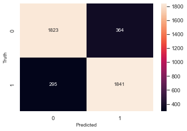

```python
cm = confusion_matrix(y_test, y_pred)

sns.heatmap(cm, annot=True, fmt='d')
plt.xlabel('Predicted')
plt.ylabel('Truth')
```

By using `GridSearchCV` function, we can get the best possible parameters for the model, which gives us the most accurate results.

Based on the researchs I did, this model has various parameters, which are described here:

- `penalty`: Penalty used for regularization (str, 'l1' or 'l2')
- `dual`: Dual or primal formulation (bool)
- `tol`: Tolerance for stopping criteria (float)
- `C`: Inverse of regularization strength (float)
- `fit_intercept`: Whether to calculate the intercept for the model (bool)
- `intercept_scaling`: Scaling factor for the intercept (float)
- `class_weight`: Weights associated with classes in the target variable (dict or 'balanced')
- `random_state`: Seed used by the random number generator (int or RandomState instance)
- `solver`: Algorithm used for optimization (str, 'newton-cg', 'lbfgs', 'liblinear', 'sag', or 'saga')
- `max_iter`: Maximum number of iterations for the solver to converge (int)
- `multi_class`: Strategy used to handle multiple classes (str, 'ovr' or 'multinomial')
- `verbose`: Verbosity mode (int)
- `warm_start`: Whether to reuse the solution of the previous call to fit as initialization (bool)
- `n_jobs`: Number of CPU cores used for parallelization (int or None)

```python
lr_params = {'penalty': ['l1', 'l2'],
             'C': [0.1, 1, 10, 100],
             'solver': ['liblinear', 'saga'],
             'max_iter': [100, 200, 300]}

lr = LogisticRegression()
lr_grid = GridSearchCV(lr, lr_params, cv=5)

lr_grid.fit(x, y)

print("Logistic Regression best parameters:", lr_grid.best_params_)
print("Logistic Regression best score:", lr_grid.best_score_)
```

```
Logistic Regression best parameters: {'C': 1, 'max_iter': 100, 'penalty': 'l1', 'solver': 'saga'}
Logistic Regression best score: 0.837736050823362
```

Overfitting and underfitting are common problems in machine learning that can affect the performance of predictive models.

- **Overfitting** occurs when a model is too complex and fits the training data too closely, to the point that it captures the noise or random fluctuations in the data rather than the underlying patterns. An overfit model may have high accuracy on the training data but poor generalization performance on new, unseen data. This is because the model has essentially memorized the training data and cannot generalize to new examples that are different from the training data. Overfitting can be caused by a wide range of factors, such as using a model that is too complex, using too many features, or not having enough data for the complexity of the model.
- **Underfitting** occurs when a model is too simple and cannot capture the underlying patterns in the data. An underfit model may have poor accuracy on both the training data and new, unseen data, because it is not able to capture the important features of the data. Underfitting can be caused by using a model that is too simple, not using enough features, or not having enough data for the complexity of the model.

The goal of machine learning is to find a model that can generalize well to new, unseen data. To achieve this, it is important to find the right balance between model complexity and the amount of data available. A model that is too complex may overfit the data, while a model that is too simple may underfit the data. One way to address overfitting is to use regularization techniques, such as `L1` or `L2` regularization, which add a penalty term to the loss function to discourage overly complex models. Another way to address overfitting is to use techniques such as `cross-validation` or `early stopping` to monitor the model performance on new, unseen data during training. To address underfitting, it may be necessary to use a more complex model or to gather more data to better capture the underlying patterns in the data.

In order to see whether overfitting or underfitting has occurred, we obtain and compare the accuracy of the models on both training and test data.

```python
knn = KNeighborsClassifier()
knn.fit(x_train, y_train)
y_pred = knn.predict(x_train)
knn_train_acc = accuracy_score(y_train, y_pred)
y_pred = knn.predict(x_test)
knn_test_acc = accuracy_score(y_test, y_pred)

dtc = DecisionTreeClassifier(max_depth=5)
dtc.fit(x_train, y_train)
y_pred = dtc.predict(x_train)
dt_train_acc = accuracy_score(y_train, y_pred)
y_pred = dtc.predict(x_test)
dt_test_acc = accuracy_score(y_test, y_pred)

lr = LogisticRegression()
lr.fit(x_train, y_train)
y_pred = lr.predict(x_train)
lr_train_acc = accuracy_score(y_train, y_pred)
y_pred = lr.predict(x_test)
lr_test_acc = accuracy_score(y_test, y_pred)

print("KNN:", knn_train_acc, "-", knn_test_acc)
print("Decision Tree:", dt_train_acc, "-", dt_test_acc)
print("Logistic Regression:", lr_train_acc, "-", lr_test_acc)
```

```
KNN: 0.8997108155002892 - 0.8584316446911867
Decision Tree: 0.8669751301330249 - 0.8746241036317373
Logistic Regression: 0.8378831694621168 - 0.8475595651168171
```

Since these values are not much different from each other, we can understand that the data is not too complex or too simple and the performance of the models on both types of training and test data is favorable, so overfitting and underfilling did not occur.

Also, we can normalize once instead of standardizing in the preprocessing stage. In this way, we can get different values. But according to my test, the standardization results were better.

##### Ensemble Learning

We use `RandomForestClassifier` function, which is in implemented in `scikit learn` library. At first, we train it with the train data and then make predictions with the generated model on the test data. Finally, we obtain the accuracy value of the model using the `accuracy_score` function.

```python
from sklearn.ensemble import RandomForestClassifier

rf = RandomForestClassifier()
rf.fit(x_train, y_train)

y_pred = rf.predict(x_test)

acc = accuracy_score(y_test, y_pred)
print("Accuracy:", acc)
```

```
Accuracy: 0.916030534351145
```

Now, using `confusion_matrix` function, we obtain the confusion matrix and display it.

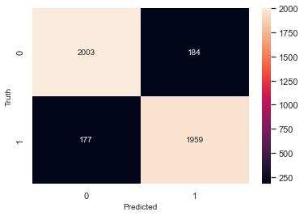

```python
cm = confusion_matrix(y_test, y_pred)

sns.heatmap(cm, annot=True, fmt='d')
plt.xlabel('Predicted')
plt.ylabel('Truth')
```

here is a list of all the hyperparameters available in scikit-learn's implementation of the random forest classifier:

- `n_estimators`: The number of decision trees in the forest.
- `criterion`: The function used to measure the quality of a split.
- `max_depth`: The maximum depth of each decision tree.
- `min_samples_split`: The minimum number of samples required to split an internal node.
- `min_samples_leaf`: The minimum number of samples required to be at a leaf node.
- `min_weight_fraction_leaf`: The minimum weighted fraction of the sum total of weights required to be at a leaf node.
- `max_features`: The number of features to consider when looking for the best split.
- `max_leaf_nodes`: The maximum number of leaf nodes in each decision tree.
- `min_impurity_decrease`: The minimum impurity decrease required to split an internal node.
- `bootstrap`: Whether bootstrap samples are used when building decision trees.
- `oob_score`: Whether to use out-of-bag samples to estimate the generalization accuracy.
- `n_jobs`: The number of jobs to run in parallel for both fit and predict.
- `random_state`: The random number generator seed used for random sampling of the training data.
- `verbose`: Controls the verbosity when fitting and predicting.
- `warm_start`: Whether to reuse the solution of the previous call to fit and add more estimators to the ensemble.